# Lab 09 - LogisticRegression

Pouria

3/28/2022

# Prompt

This dataset contain the data related to the passengers of the Titanic. The goal is to see if we are able to build a model that can predict whether or not a passenger would survive. The `Survived` column of this dataset reflects if they really survived or not (`1`: survived, and `0`: didn’t survive).

1. Load the attached csv file into your Markdown accounting for the missing values.
2. Preprocess the data.
- Check for the missing values for each variable.
- Use `missmap()` to visualize the missing values.
- Reasonably ignore variables that probably do not affect the predictions.
- Impute the missing values in the numeric (continuous) variables. Only `Age` here.
- Remove any of the rows with `NA` in their categorical variables (any categorical variable that is left in your data after leaving the unnecessary ones out).
3. Split the data up into the training and test set. (`set.seed = 1`).
- Sample 100 rows from the data and use as your test set. Use the rest as your training set.
4. Fit a logistic regression model onto the training set
- Fit and summarize the model to predict `Survived` as a function of all other remaining variables.
- Use `anova()` to see the effect of each variable on the residual deviance.
- Obtain pseudo-R2 of the model, e.g., McFadden R2.
5. Evaluate your model on the test set.
- Calculate the misclassification error on your test set with `threshold = 0.5`
- the accuracy result your obtained depends on the test set – so, now re-estimate the accuracy with a 10-fold CV
- Compute the confusion matrix for the model with the test set.
- Use library `ROCR` to plot ROC curve and also obtain the AUC of your model.
6. Redo the last two steps with only `Pclass` and `Age`.
- At last, plot the ROC curve from the two models on the same figure. What do you conclude?

# 1. Import/read the data.

Load the attached csv file into your Markdown accounting for the missing values.

## Import the csv file

Let’s import the training data here:

# 2. Preprocess the data.

## Missing values

- Check for the missing values for each variable.

## Raw data

```
##   PassengerId Survived Pclass
## 1           1        0      3
## 2           2        1      1
## 3           3        1      3
## 4           4        1      1
## 5           5        0      3
## 6           6        0      3
##                                                  Name    Sex Age SibSp Parch
## 1                             Braund, Mr. Owen Harris   male  22     1     0
## 2 Cumings, Mrs. John Bradley (Florence Briggs Thayer) female  38     1     0
## 3                              Heikkinen, Miss. Laina female  26     0     0
## 4        Futrelle, Mrs. Jacques Heath (Lily May Peel) female  35     1     0
## 5                            Allen, Mr. William Henry   male  35     0     0
## 6                                    Moran, Mr. James   male  NA     0     0
##             Ticket    Fare Cabin Embarked
## 1        A/5 21171  7.2500  <NA>        S
## 2         PC 17599 71.2833   C85        C
## 3 STON/O2. 3101282  7.9250  <NA>        S
## 4           113803 53.1000  C123        S
## 5           373450  8.0500  <NA>        S
## 6           330877  8.4583  <NA>        Q
```

## Leave out irrelevant variables

- Ignore/leave out the variables `PassengerID`, `Cabin`, `Ticket`, and `Name`.

```
##  [1] "PassengerId" "Survived"    "Pclass"      "Name"        "Sex"
##  [6] "Age"         "SibSp"       "Parch"       "Ticket"      "Fare"
## [11] "Cabin"       "Embarked"
```

```
##   Survived Pclass    Sex Age SibSp Parch    Fare Embarked
## 1        0      3   male  22     1     0  7.2500        S
## 2        1      1 female  38     1     0 71.2833        C
## 3        1      3 female  26     0     0  7.9250        S
## 4        1      1 female  35     1     0 53.1000        S
## 5        0      3   male  35     0     0  8.0500        S
## 6        0      3   male  NA     0     0  8.4583        Q
```

## Visualize missing values

- Use `missmap()` to visualize the missing values.

We can also visualize the missing values using the function `missmap()`.

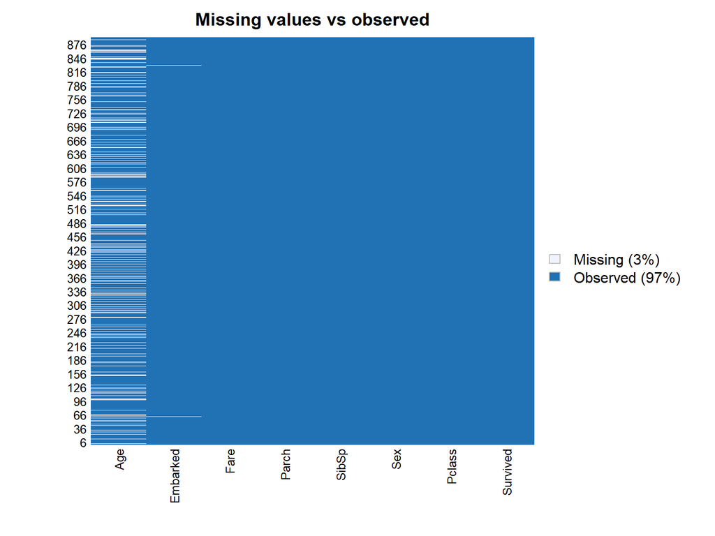

## Impute the missing values

- Only keep those rows that are not `NA` in `Embarked`
- Then, impute the missing values in `Age` with mean value.

```
##   Survived Pclass    Sex      Age SibSp Parch    Fare Embarked
## 1        0      3   male 22.00000     1     0  7.2500        S
## 2        1      1 female 38.00000     1     0 71.2833        C
## 3        1      3 female 26.00000     0     0  7.9250        S
## 4        1      1 female 35.00000     1     0 53.1000        S
## 5        0      3   male 35.00000     0     0  8.0500        S
## 6        0      3   male 29.64209     0     0  8.4583        Q
```

# 3. Split the data

Split the data up into the training and test set. (`set.seed = 1`).

## Split the data

- Sample 100 rows from the data and use as your test set. Use the rest as your training set.

# 4. Fit a logistic regression model onto the training set

## Pseudo-R2

# 5. Evaluate your model on the test set.

## Confusion Matrix

You may use either `table()` or `confusionMatrix()` to obtain the confusion matrix.

## Plot ROC

- Use library **ROCR** to plot ROC curve.

Use `prediction()` and then pass its output to `performance()` to obtain the true positive rate (`"tpr"`) and false positive rate (`"fpr"`) values for different thresholds. Notice that you will not have to worry about setting thresholds. `performance()` will automatically try different thresholds and accordingly return the rate values in two arrays that are accessible by `@` (instead of `$`).

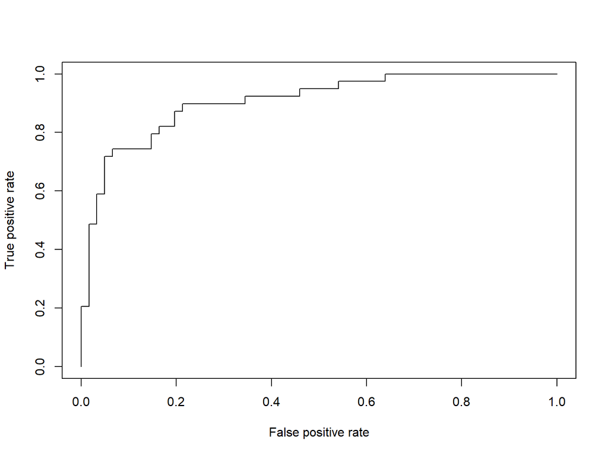

## Calculate the accuracy using CV error

# 6. Fit a new model

- Redo the last two steps with only `Pclass` and `Age`.

## Implement a new fit with `Pclass` and `Age`

Do the fit again with only `Pclass` and `Age`;

## Confusion Matrix

## ROC Curve

Plot ROC for this new model on top of the ROC curve for the full model - what do you conclude?

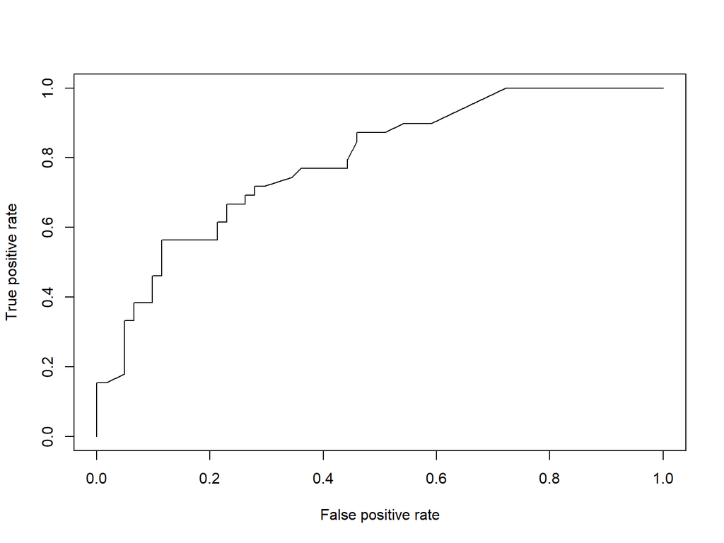

```
## [1] 0.7881463
```

## Both ROC Curves

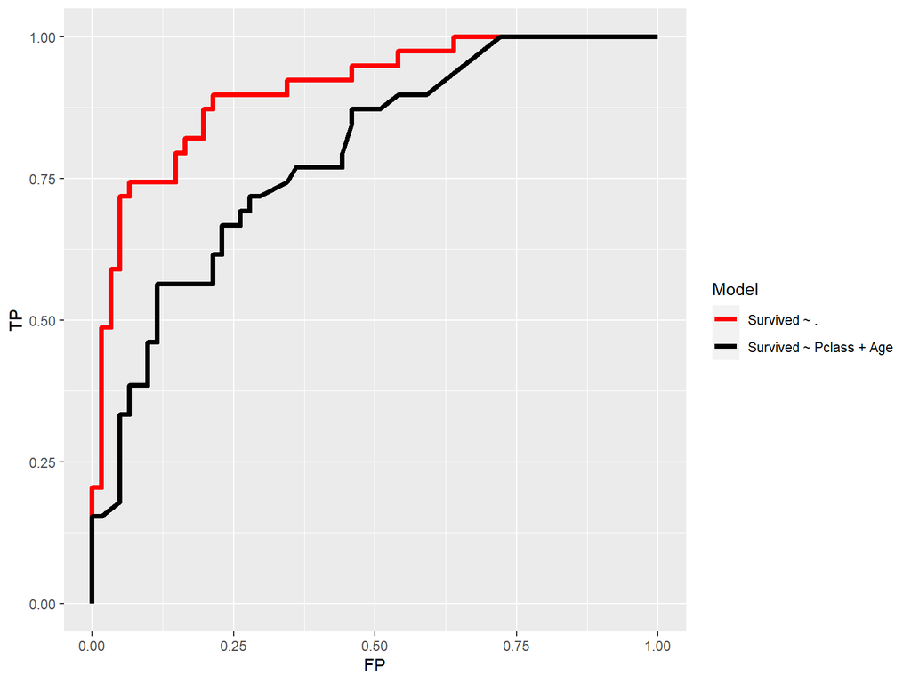